# Chapter 11 Homework

AP

2/14/2022

## Question 1

Just control for university, because those campus-specific variables that you want to control for will be the same for everyone inside the same university (essentially, do a fixed-effects model where you sample a bunch of universities over time and then control for university).

## Question 2

Honestly, I don’t know, but here’s a stab in the dark: In theory, if we can isolate only front door paths, the back door paths are all closed anyway because of colliders along the way (like we talked about in Ch. 9 with sources of exogenous variation).

## Question 3

Robustness tests are tests that confirm the validity of assumptions we’re making by rerunning the analysis without relying on those assumptions.

We conduct robustness tests to make sure that our assumptions aren’t leading us to a false result.

Placebo tests are when you pretend you assign treatment somewhere you don’t; if you get an effect, one of your underlying assumptions is wrong.

## Question 4

Student motivation, number of extracurriculars, behavior of close friends, number of alcoholic drinks a week, parents’ educational experiences. It probably would not be feasible to measure all of these, although it is possible.

## Question 5

Partial identification is when you make the assumptions you’re sure about and control for what you can, and then use what you know about unmeasured variables to give a range of plausible values as your effect size.

## Question 6

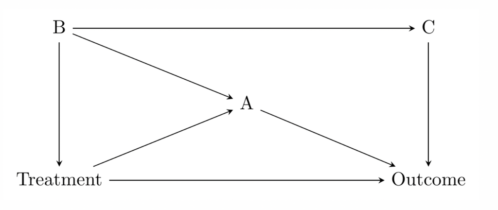

Treatment and C have no direct link. If I controlled for B, that would remove all active paths between Treatment and C (on all others, outcome is a collider). If I tested this relationship while controlling for B and found a nonzero relationship, there’s a line missing from my DAG.

## Question 7

D